# Practical Machine Learning Coursera Project

Arnulfo Perez

17/5/2020

## Background

Using devices such as Jawbone Up, Nike FuelBand, and Fitbit it is now possible to collect a large amount of data about personal activity relatively inexpensively. These type of devices are part of the quantified self movement – a group of enthusiasts who take measurements about themselves regularly to improve their health, to find patterns in their behavior, or because they are tech geeks. One thing that people regularly do is quantify how much of a particular activity they do, but they rarely quantify how well they do it. In this project, your goal will be to use data from accelerometers on the belt, forearm, arm, and dumbell of 6 participants. They were asked to perform barbell lifts correctly and incorrectly in 5 different ways. More information is available from the website here: http://groupware.les.inf.puc-rio.br/har (see the section on the Weight Lifting Exercise Dataset (Groupware 2013),(Velloso 2012),(Velloso 2013)).

## Weight Lifting Exercises Dataset

Six young health participants were asked to perform one set of 10 repetitions of the Unilateral Dumbbell Biceps Curl in five different fashions: exactly according to the specification (Class A), throwing the elbows to the front (Class B), lifting the dumbbell only halfway (Class C), lowering the dumbbell only halfway (Class D) and throwing the hips to the front (Class E). Class A corresponds to the specified execution of the exercise, while the other 4 classes correspond to common mistakes. Participants were supervised by an experienced weight lifter to make sure the execution complied to the manner they were supposed to simulate. The exercises were performed by six male participants aged between 20-28 years, with little weight lifting experience. We made sure that all participants could easily simulate the mistakes in a safe and controlled manner by using a relatively light dumbbell (1.25kg).

## Loading the data

The data is available in two files, a training dataset that includes the class labels for training purposes, and a testing file with the class labels omitted.

```r
training <- read.csv(training_csv)
testing <- read.csv(testing_csv)

dim(training)
```

```
## [1] 19622   160
```

```r
dim(testing)
```

```
## [1]  20 160
```

```r
names(training)
```

```
##   [1] "X"                        "user_name"
##   [3] "raw_timestamp_part_1"     "raw_timestamp_part_2"
##   [5] "cvtd_timestamp"           "new_window"
##   [7] "num_window"               "roll_belt"
##   [9] "pitch_belt"               "yaw_belt"
##  [11] "total_accel_belt"         "kurtosis_roll_belt"
##  [13] "kurtosis_picth_belt"      "kurtosis_yaw_belt"
##  [15] "skewness_roll_belt"       "skewness_roll_belt.1"
##  [17] "skewness_yaw_belt"        "max_roll_belt"
##  [19] "max_picth_belt"           "max_yaw_belt"
##  [21] "min_roll_belt"            "min_pitch_belt"
##  [23] "min_yaw_belt"             "amplitude_roll_belt"
##  [25] "amplitude_pitch_belt"     "amplitude_yaw_belt"
##  [27] "var_total_accel_belt"     "avg_roll_belt"
##  [29] "stddev_roll_belt"         "var_roll_belt"
```

[output cut: 65 more lines]

## Preprocessing

```r
data<- training[, colSums(is.na(training)) == 0]
validationData <- testing[, colSums(is.na(testing)) == 0]
data <- data[, -c(1:7)]
validationData <- validationData[, -c(1:7)]


data$classe <- factor(data$classe)
validationData$problem_id <- factor(validationData$problem_id)
```

## Data splitting

Because we are required to use Random Forest with cross validation, I keep 70% of the data for training, and 30% for testing.

```r
inTraining <- createDataPartition(data$classe, p = 0.7, list = FALSE)
trainData <- data[inTraining, ]
testData <- data[-inTraining, ]

NZV <- nearZeroVar(trainData)
trainData <- trainData[, -NZV]
testData  <- testData[, -NZV]

dim(trainData)
```

```
## [1] 13737    53
```

```r
dim(testData)
```

```
## [1] 5885   53
```

## Random Forest with cross validation

The caret function trainControl allows one to set the training sequence. Here, I am setting 3-fold cross validation, set arbitrarily from typical values.

```r
#10 folds repeat 3 times
control <- trainControl(method='cv', number=3)
```

Then the train function can be called with the “rf” method, and the control parameters set with the trainControl function.

```r
set.seed(12345)
modelRF <- train(classe ~ ., data=trainData, method="rf", trControl=control)
modelRF$finalModel
```

```
##
## Call:
##  randomForest(x = x, y = y, mtry = param$mtry)
##                Type of random forest: classification
##                      Number of trees: 500
## No. of variables tried at each split: 27
##
##         OOB estimate of  error rate: 0.71%
## Confusion matrix:
##      A    B    C    D    E class.error
## A 3901    4    1    0    0 0.001280082
## B   18 2629   10    1    0 0.010910459
## C    0   14 2373    9    0 0.009599332
## D    0    3   22 2226    1 0.011545293
## E    0    1    5    8 2511 0.005544554
```

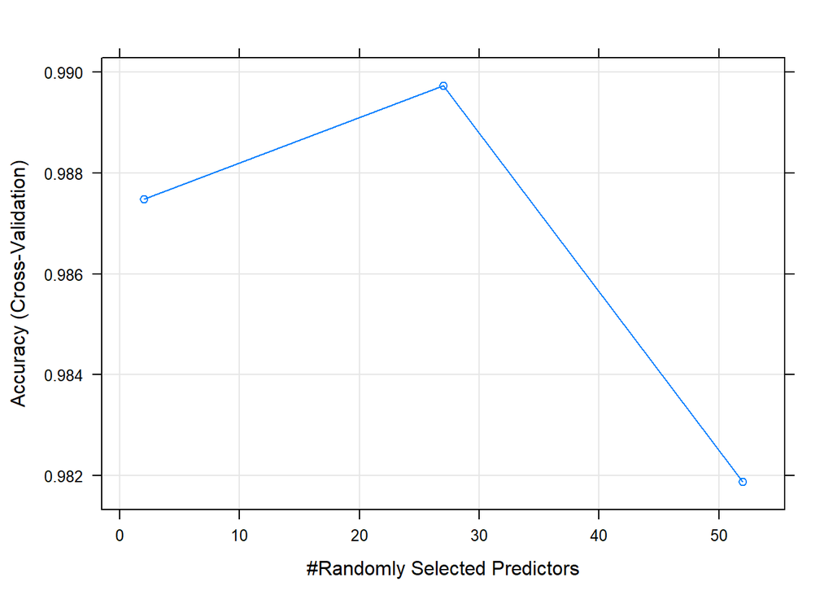

```r
plot(modelRF)
```

Now I can use the testing dataset to check the accuracy of the model’s predictions.

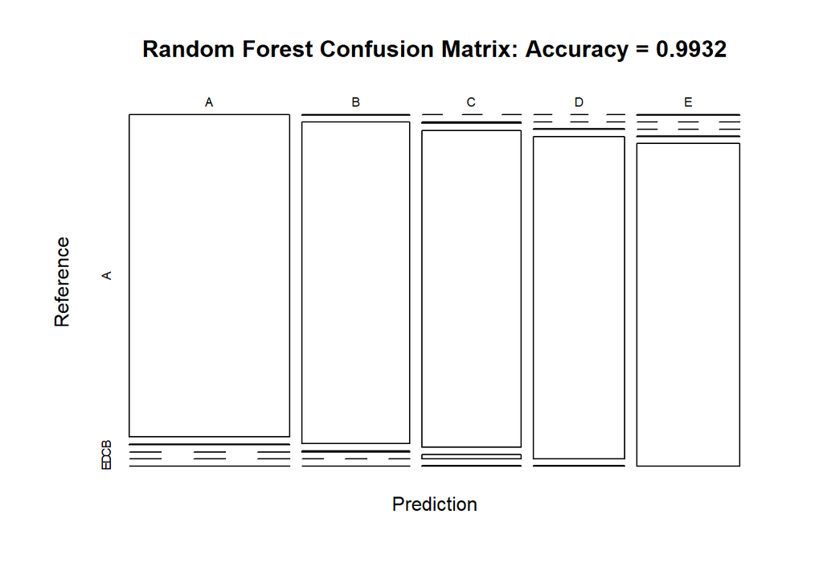

```r
prediction <- predict(modelRF, newdata=testData)
confusion <- confusionMatrix(prediction, testData$classe)
plot(confusion$table, col = confusion$byClass,
     main = paste("Random Forest Confusion Matrix: Accuracy =",
                  round(confusion$overall['Accuracy'], 4)))
```

## Validation values

```r
validation <- predict(modelRF, newdata=validationData)
table(validationData$problem_id,validation)
```

```
##     validation
##      A B C D E
##   1  0 1 0 0 0
##   2  1 0 0 0 0
##   3  0 1 0 0 0
##   4  1 0 0 0 0
##   5  1 0 0 0 0
##   6  0 0 0 0 1
##   7  0 0 0 1 0
##   8  0 1 0 0 0
##   9  1 0 0 0 0
##   10 1 0 0 0 0
##   11 0 1 0 0 0
##   12 0 0 1 0 0
##   13 0 1 0 0 0
##   14 1 0 0 0 0
##   15 0 0 0 0 1
##   16 0 0 0 0 1
##   17 1 0 0 0 0
##   18 0 1 0 0 0
##   19 0 1 0 0 0
##   20 0 1 0 0 0
```

## Conclusions

The Random Forest classifier has an almost perfect accuracy on the Weight Lifting Exercises Dataset, using default parameters of the caret package functions for training classifiers. This performance is due to the capabilities of the Random Forest classifier, but mainly to the good experiment design of the Groupwise@LES research group (Velloso 2013). Nonetheless, classification is sutle and overfitting is always a concern.

# References

Groupware. 2013. “Human Activity Recognition.” http://groupware.les.inf.puc-rio.br/har#sbia_paper_section.

Velloso, A.; Gellersen, E.; Bulling. 2012. “Wearable Computing: Accelerometers’ Data Classification of Body Postures and Movements.” In *Proceedings of 21st Brazilian Symposium on Artificial Intelligence. Advances in Artificial Intelligece - Sbia 2012*, 52–61. Lecture Notes in Computer Science. Curitiba, Brazil: Springer Berlin. \url{http://groupware.les.inf.puc-rio.br/har#sbia_paper_section#ixzz6MknrA4XH}.

———. 2013. “Qualitative Activity Recognition of Weight Lifting Exercises.” In *Proceedings of 4th International Conference in Cooperation with Sigchi (Augmented Human ’13).* Stuttgart, Germany: ACM SIGCHI. \url{http://groupware.les.inf.puc-rio.br/har#sbia_paper_section#ixzz6MkoKaZCK}.